# 440 CS3 Final Report

Jake Epstein, Man-Lin Hsiao, Sahil Patel, Daniel Spottiswood, & Michael Tan

10/22/2019

### Introduction

This case study aims to obtain robust estimates for mortality rates by race and year across North Carolina counties based on 2011-2016 mortality data from the North Carolina Center for Health Statistics. We supplemented this data with health and demographic data from a study performed by the Robert Wood Johnson Foundation. We explored correlations between mortality rate and percent insured, median household income, percent low birth weight, percent obese, and percent smokers. Through EDA and model fitting, we narrowed these features down and created a model that predict mortality rates by race, year and county, utilizing percent low birth weight, percent smokers, and median household income. We then comment on trends by group over time and compare those trends to the national averages.

### Exploratory Data Analysis

#### Initial Visualization

[figure not shown]

The visualizations above are captured from our tableau dashboard. The map depicts the **large variance in number of births and mortality rates across the different counties.** The largest counties, based on births, appear in lighter colors - they have relatively lower mortality rates, while we see darker colors, which are spikes in mortality rate, in many of those with smaller populations. This variation in mortality rates is likely the result of smaller sample sizes in these counties, but higher mortality rates in small counties could possibly be attributed to differences in medical resources in these areas. From the bar charts, we also see that there are **substantially more white births** (382,602) than any other race, specifically, we have very few data points for American Indians and people that identify as other non-white. On the other hand, **the overall mortality rate for each year from 2011 to 2016 stays fairly constant**.

The high variance in births per county paired with the aforementioned variance in births by race, underscores **the need to share some, but not all, information at the county level and by race**.

#### Exploring Categorical Variables

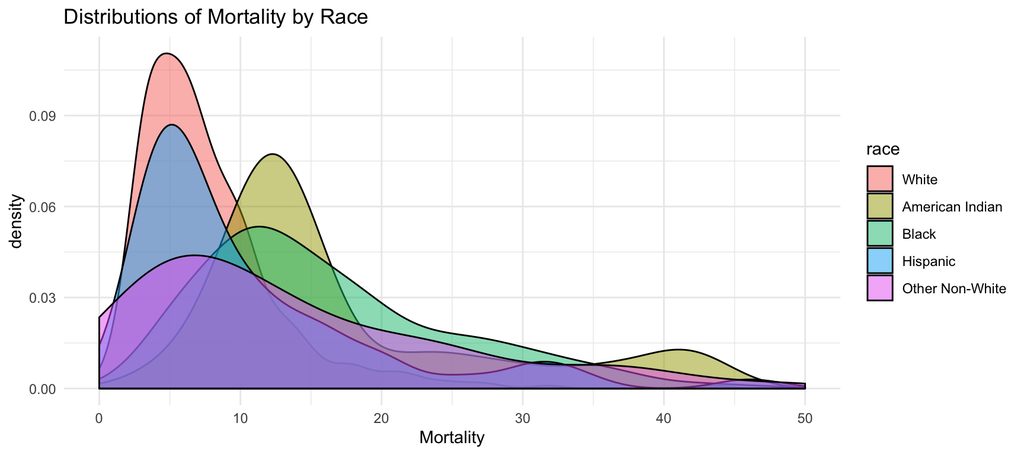

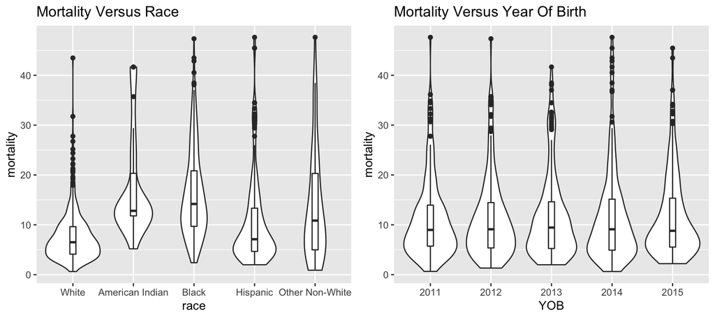

The above plots confirm several observations we were able to make in our tableau dashboard, while also providing additional visualizations on distributional information.

The second violin plots show similar distributions of mortality rates across time. Here we can understand that **not only the number of births, but also mortality rates on an aggreggated basis within North Carolina throughout the years do stay fairly consistent and have no notable swings**.

#### Exploring Numerical Continuous Variables

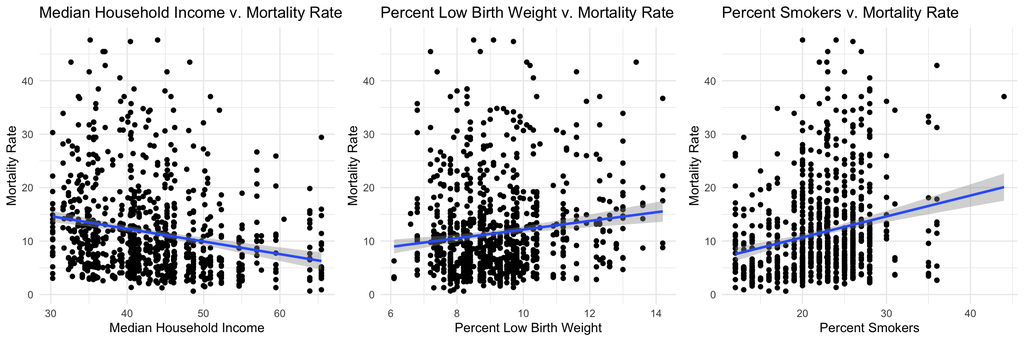

As shown in the scatterplots above, there is a positive relationship between mortality rate with percentage of smokers (correlation of 0.2182623) as well as percentage of births that had a low birth weight (correlation of 0.1377997). On the other hand, there is a negative relationship between the median household income and the mortality rate in that county (correlation of -0.2169295). These relationships suggest a possibility of incorporating these factors as appropriate predictors in our model.

### Model Selection

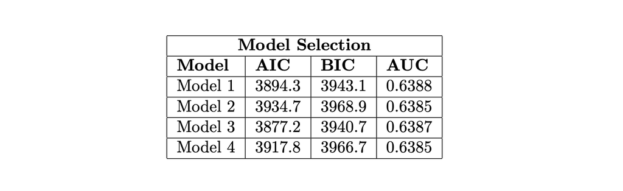

**Model 1**: Mortality Rate ~ (1 | County) + (1 | Race) + Year + Median Household Income + Percent Low Birthweight + Percent Smokers

**Model 2**: Mortality Rate ~ (1 | County) + (1 | Race) + Year

**Model 3**: Mortality Rate ~ (1 | County) + Race + Year + Median Household Income + Percent Low Birthweight + Percent Smokers

**Model 4**: Mortality Race ~ (1 | County) + Race + Year

We trained four separate models on the 2011-2015 data and then tested on the 2016 data. We used three statistics to assess model fit/accuracy: AIC, BIC, and AUC, which are shown above. All four models use random effects at the county level, but differ in how they model race and whether or not they make use of the additional features: median income, smoking, and low birth weight. Models 1 and 2 use a random effect to model race, while 3 and 4 use a fixed effect. Models 1 and 3 make use of the additional features, while 2 and 4 do not.

### Model Interpretation

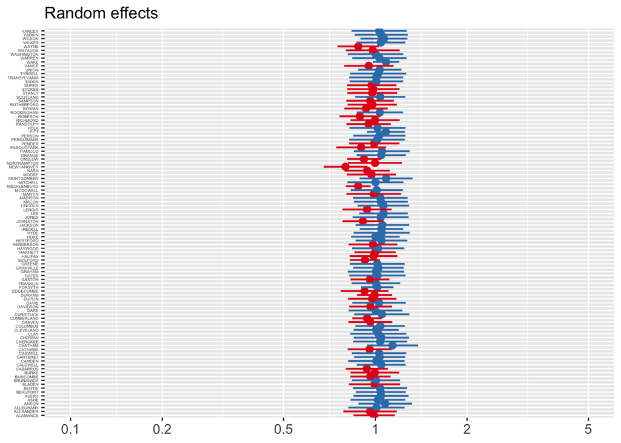

[figure not shown]

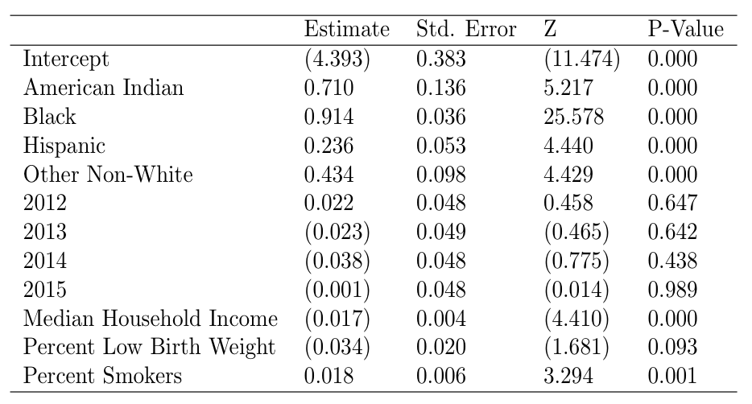

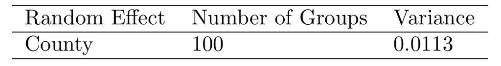

The model with race fixed revealed the following statistically significant effects:

For a given county, race, year of birth, percentage of births in a county that have low birth weight, and percentage of people in a county who are smokers, a one thousand dollar increase in median household income leads to 0.983x the probability of mortality (changed by a multiplicative factor of e^-0.0174654 = 0.983). This is a significant effect at a 0.001 significance-level.

The explanation of this effect (median income) seems intuitive. It could be the case that becoming wealthier leads to being able to afford better obstetrics (birthing and pregnancy) services, which would lead to a decreased probability of a baby dying.

For a given county, race, year of birth, median household income in a county, and percentage of people in a county who are smokers, a one percent increase in the percentage of births that have low birth weight leads to 0.967x the probability of mortality (changed by a multiplicative factor of e^-0.0337263 = 0.967). This effect has a p-value of 0.093, and does not meet the signficance threshold of 0.05.

The explanation of this effect (% low birth weight) seems counterintuitive. It could be the case that families that know they will have a baby with low birth weight (mothers that know they will give birth early) will prepare for such a situation by picking a higher-quality obstetrics service, which would lead to a decreased probability of a baby dying. The effect is also not significant.

For a given county, race, year of birth, median household income in a county, and percentage of births in a county that have low birth weight, a one percent increase in the percentage of people who are smokers leads to 1.019x the probability of mortality (changed by a multiplicative factor of e^0.0183569 = 1.019). This is a significant effect at a 0.001 significance-level.

The explanation of this effect (% smokers) seems intuitive. Smoking is detrimental to health. It has scientifically been shown that smoking by a pregnant mother is especially bad for the unborn fetus.

In addition, we see that holding all else constant, we predict American Indian’s and African American’s to experience the largest mortality rate, while we predict whites to experience the least. For example, holding all else equal, an African American would experience a mortality rate that is 2.5 times that of a white person (e^0.9138114 = 2.5).

The county level variability is 0.01127.

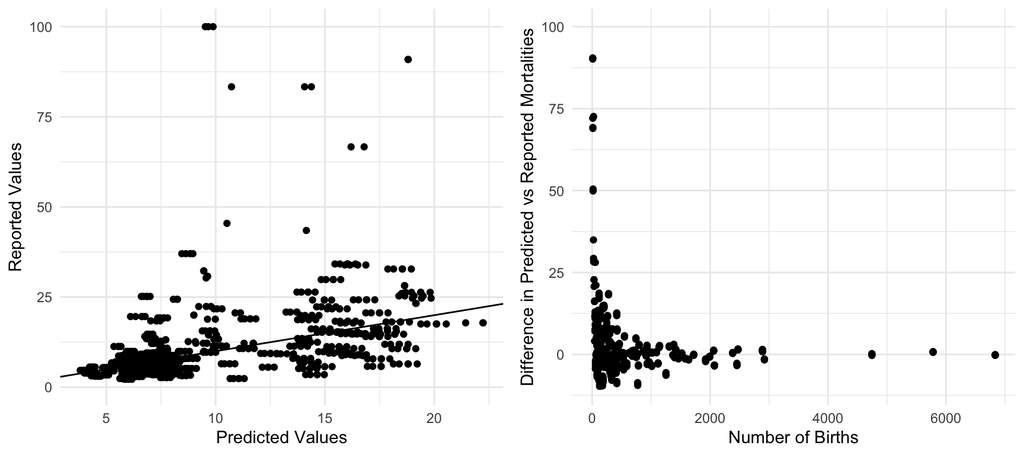

### Conclusion and Trends

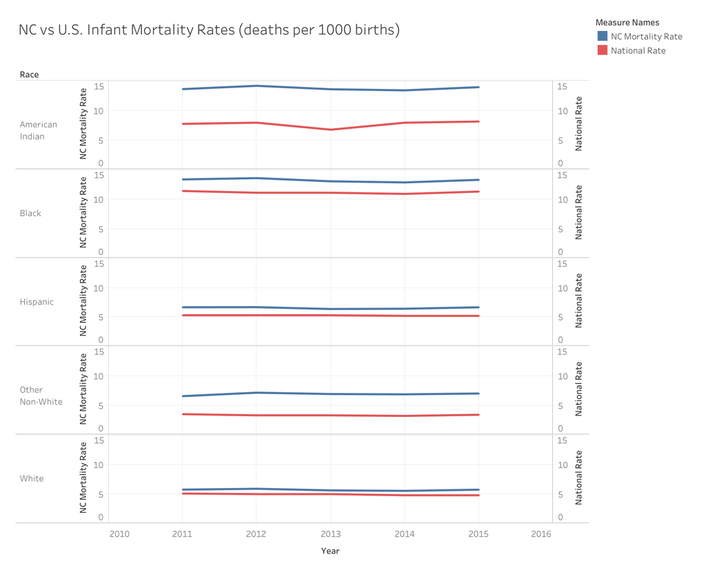

In the above visualization, we compare our predictions by race and year to U.S. rates overall. We obtained this national data from the Centers for Disease Control and Prevention. As shown by our exploratory analysis and our model, year dpoes not have a significant relationship with infant mortality, and unsurprisingly there are no large directional trends in infant mortality for any racial group over time in North Carolina. This is consistent with what has been seen in the U.S. in a whole, as the mortality rate for each race has remained essentially constant over this time period.

Infant mortality rates in North Carolina are higher than those of the U.S. overall for every category of race. Our North Carolina estimates are relatively similar to those for the U.S. overall for white, black and hispanic populations, but our predictions diverge greatly in the other non-white category and the American Indian category. One possible explanations for this large divergence is the relatively small sample size of American Indian and other non-white individuals in our data in comparison to white individuals. Further research is advised to explore why North Carolina has experienced higher rates of infant mortality. One possible routes of exploration would be looking into differences in poverty rates and access to medical care across various states.